# Getting Started with lwdid

## Introduction

The **lwdid** package implements the Lee and Wooldridge (2025, 2026) simple transformation approach for Difference-in-Differences (DiD) estimation with panel data. The key innovation is a unit-level time-series transformation that converts panel DiD into a cross-sectional treatment effects problem.

**Key features:**

- **Two designs**: Common Timing and Staggered Adoption
- **Four estimators**: RA, IPW, IPWRA, PSM
- **Robust inference**: HC0–HC4, cluster-robust, Wild Cluster Bootstrap, Fisher Randomization Inference
- **Exact small-sample inference**: valid even with $N_1 = 1$
- **Diagnostics**: parallel trends tests, sensitivity analysis, clustering diagnostics

## Installation

```r
# From GitHub
# install.packages("devtools")
devtools::install_github("gorgeousfish/lwdid-r")
```

## Data Format

lwdid requires **long-format panel data** where each row is one unit-period observation. Required columns:

| Role | Parameter | Type |
| --- | --- | --- |
| Unit ID | `ivar` | integer or character |
| Time | `tvar` | integer |
| Outcome | `y` | numeric |
| Treatment (Common Timing) | `d` + `post` | binary (0/1) |
| Treatment (Staggered) | `gvar` | integer or NA |

## Demean vs Detrend

The `rolling` parameter controls pre-treatment transformation:

- **`"demean"`** (default): Subtracts the pre-treatment mean. Requires parallel trends. At least 1 pre-treatment period.
- **`"detrend"`**: Removes unit-specific linear trends. Allows heterogeneous trends. At least 2 pre-treatment periods.

## Common Timing: California Proposition 99

The `smoking` dataset contains the classic California tobacco control study (1970–2000). California is the sole treated state ($N_1 = 1$), with treatment starting in 1989.

```r
library(lwdid)
data(smoking)

result <- lwdid(
  data = smoking,
  y = "lcigsale",
  ivar = "state",
  tvar = "year",
  d = "d",
  post = "post",
  rolling = "demean",
  estimator = "ra"
)

print(result)
```

```
#>
#> Lee-Wooldridge DiD Estimation
#> ==============================================================================
#>   Method:       common_timing            Dep. var:      lcigsale
#>   Estimator:    ra                       VCE:           homoskedastic
#>   Transform:    demean                   df:            37
#>   Pre-periods:  K = 19                   Post start:    tpost1 = 20
#> ------------------------------------------------------------------------------
#>
#> Overall ATT:
#>                 Estimate  Std. Err.    t value Pr(>|t|)       CI lower   CI upper
#>   ATT        -0.4222     0.1208    -3.4948   0.0012  **    -0.6669    -0.1774
#>   ---
#>   Signif. codes:  0 '***' 0.001 '**' 0.01 '*' 0.05 '.' 0.1 ' ' 1
#>
#> Regression Coefficients:
#>   ----------------------------------------------------------
#>   Term               Estimate  Std. Err.    t value Pr(>|t|)
#>   ----------------------------------------------------------
#>   (Intercept)         -0.2462
#>   D                   -0.4222
#>   ----------------------------------------------------------
#>
#> Period-Specific Effects:
#>   ----------------------------------------------------------------------------
#>     Period        ATT  Std. Err.     t-stat  p-value       CI lower   CI upper
#>   ----------------------------------------------------------------------------
#>       1989    -0.1682     0.0958    -1.7559   0.0874   .    -0.3623     0.0259
#>       1990    -0.1875     0.1117    -1.6788   0.1016        -0.4138     0.0388
#>       1991    -0.3025     0.1167    -2.5919   0.0136   *    -0.5389    -0.0660
#>       1992    -0.3101     0.1280    -2.4224   0.0204   *    -0.5695    -0.0507
#>       1993    -0.3668     0.1212    -3.0266   0.0045  **    -0.6123    -0.1212
#>   ... (7 more periods)
#>   ----------------------------------------------------------------------------
#>   Period-by-period effects are available in results$att_by_period.
#> ==============================================================================
#>   N = 39    N_treated = 1    N_control = 38    K = 19    tpost1 = 20
```

### Detrending

When unit-specific trends are suspected:

```r
result_dt <- lwdid(
  data = smoking,
  y = "lcigsale",
  ivar = "state",
  tvar = "year",
  d = "d",
  post = "post",
  rolling = "detrend",
  estimator = "ra"
)

summary(result_dt)
```

```
#>
#> Lee-Wooldridge DiD Estimation
#> ==============================================================================
#>   Method:       common_timing            Dep. var:      lcigsale
#>   Estimator:    ra                       VCE:           homoskedastic
#>   Transform:    detrend                  df:            37
#>   Pre-periods:  K = 19                   Post start:    tpost1 = 20
#> ------------------------------------------------------------------------------
#>
#> Overall ATT:
#>                 Estimate  Std. Err.    t value Pr(>|t|)       CI lower   CI upper
#>   ATT        -0.2270     0.0941    -2.4130   0.0209   *    -0.4176    -0.0364
#>   ---
#>   Signif. codes:  0 '***' 0.001 '**' 0.01 '*' 0.05 '.' 0.1 ' ' 1
#>
#> Regression Coefficients:
#>   ----------------------------------------------------------
#>   Term               Estimate  Std. Err.    t value Pr(>|t|)
#>   ----------------------------------------------------------
#>   (Intercept)         -0.1924
#>   D                   -0.2270
#>   ----------------------------------------------------------
#>
#> Period-Specific Effects:
#>   ----------------------------------------------------------------------------
#>     Period        ATT  Std. Err.     t-stat  p-value       CI lower   CI upper
#>   ----------------------------------------------------------------------------
#>       1989    -0.0423     0.0593    -0.7129   0.4804        -0.1624     0.0779
#>       1990    -0.0490     0.0818    -0.5989   0.5529        -0.2146     0.1167
#>       1991    -0.1514     0.0733    -2.0638   0.0461   *    -0.3000    -0.0028
#>       1992    -0.1464     0.0874    -1.6757   0.1022        -0.3235     0.0306
#>       1993    -0.1905     0.0911    -2.0918   0.0434   *    -0.3750    -0.0060
#>       1994    -0.2508     0.0960    -2.6131   0.0129   *    -0.4453    -0.0563
#>       1995    -0.2820     0.1121    -2.5152   0.0164   *    -0.5092    -0.0548
#>       1996    -0.2834     0.1233    -2.2982   0.0273   *    -0.5333    -0.0335
#>       1997    -0.2867     0.1353    -2.1191   0.0409   *    -0.5608    -0.0126
#>       1998    -0.2916     0.1438    -2.0274   0.0499   *    -0.5830    -0.0002
#>       1999    -0.3469     0.1571    -2.2088   0.0335   *    -0.6651    -0.0287
#>       2000    -0.4029     0.1525    -2.6426   0.0120   *    -0.7118    -0.0940
#>   ----------------------------------------------------------------------------
#>   Period-by-period effects are available in results$att_by_period.
#> ==============================================================================
#>   N = 39    N_treated = 1    N_control = 38    K = 19    tpost1 = 20
```

## Staggered Adoption: Castle Doctrine Laws

The `castle` dataset examines the effect of Castle Doctrine laws on homicide rates across US states. States adopted the law at different times between 2005 and 2009.

```r
data(castle)

result_stag <- lwdid(
  data = castle,
  y = "lhomicide",
  ivar = "sid",
  tvar = "year",
  gvar = "gvar",
  rolling = "demean",
  estimator = "ra",
  aggregate = "cohort"
)

print(result_stag)
```

```
#>
#> Lee-Wooldridge DiD Estimation
#> ==============================================================================
#>   Method:       staggered                Dep. var:      lhomicide
#>   Estimator:    ra                       VCE:           homoskedastic
#>   Transform:    demean                   df:            29
#>   Design:       Staggered DID            Aggregate:     cohort
#>   Aggregation:  cohort
#>   Sample:       Units: 50 | Periods: 11 | Cohorts: 5 | NT: 29 | N Never-treated: 29
#>   Cohorts:      2005, 2006, 2007, 2008, 2009
#>   Control:      never_treated [auto-switched from not_yet_treated] N Never-treated: 29
#> ------------------------------------------------------------------------------
#>
#> Overall ATT:
#>                 Estimate  Std. Err.    t value Pr(>|t|)       CI lower   CI upper
#>   ATT         0.0917     0.0512     1.7927   0.0835   .    -0.0129     0.1964
#>   ---
#>   Signif. codes:  0 '***' 0.001 '**' 0.01 '*' 0.05 '.' 0.1 ' ' 1
#>
#> Cohort Effects:
#>   --------------------------------------------------------------------------------------------
#>     Cohort N_units Periods        ATT  Std. Err.     t-stat  p-value       CI lower   CI upper
#>   --------------------------------------------------------------------------------------------
#>       2005       1       6     0.0802     0.1731     0.4632   0.6468        -0.2743     0.4346
#>       2006      13       5     0.0682     0.0722     0.9450   0.3503        -0.0777     0.2142
#>       2007       4       4     0.1141     0.0900     1.2676   0.2144        -0.0695     0.2976
#>       2008       2       3     0.1460     0.1396     1.0459   0.3042        -0.1395     0.4316
#>       2009       1       2     0.2111     0.1910     1.1049   0.2786        -0.1803     0.6024
#>   --------------------------------------------------------------------------------------------
#> ==============================================================================
#>   N = 550    N_treated = 21    N_control = 29
#>   Hint: coef(x, type='all') for (g,r)-level effects, plot(x) for event study
```

For a single `aggregate = "overall"` summary, lwdid weights cohort-time effects by treated-unit cohort sizes. Exports keep those `cohort_weights`; `effective_weights` report the post-estimation sample weights if observations are dropped from the regression sample.

### Event Study

Event-study plots use relative event time. By default, the plot adds a visual anchor at event time `-1` when pre-treatment periods are displayed and no observed `-1` row is already in the plotted data. If you hide pre-treatment periods, the anchor is also omitted. A `ref_period` normalizes estimates to an observed event time, must be present in the plotted data, and does not relabel that observed row as a visual anchor.

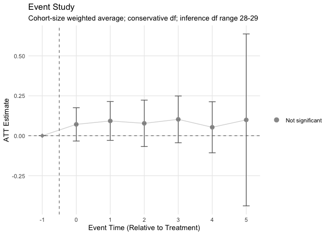

```r
result_event <- lwdid(
  data = castle,
  y = "lhomicide",
  ivar = "sid",
  tvar = "year",
  gvar = "gvar",
  rolling = "demean",
  estimator = "ra",
  aggregate = "event_time"
)

plot(result_event)
```

For `aggregate = "event_time"`, the printed scalar ATT summarizes valid cohort-period `(g, r)` effects. The event-study table and plot report WATT(e) rows by relative time, with cohort-size weights renormalized over the cohorts available at each event time. WATT(e) standard errors use the stored cohort-specific standard errors with diagonal aggregation; cross-cohort covariance is not modeled unless a future joint covariance representation is added.

Use `extract_effects(result_event, type = "event_time_contributions")` to inspect the cohort weights and cohort-specific contributions behind each WATT(e) row. The same contribution table can be written with `to_csv(result_event, file = "event-time-contributions.csv", what = "event_time_contributions")` or read from `to_dict(result_event)$event_time_contributions`. Use `to_latex(result_event, include_event_time = TRUE)` to export the WATT(e) rows with standard errors, confidence intervals, contributing-cohort counts, and compact support/overlap metadata. Plot data returned by `plot_event_study(result_event, return_data = TRUE)` carries the same standard-error metadata for the plotted event-time rows, including `se_aggregation` and `covariance_assumption`. For non-RA event-time results, the returned plot data also preserves available overlap and support-count summaries, such as propensity-score ranges, weight dispersion, and treated/control counts.

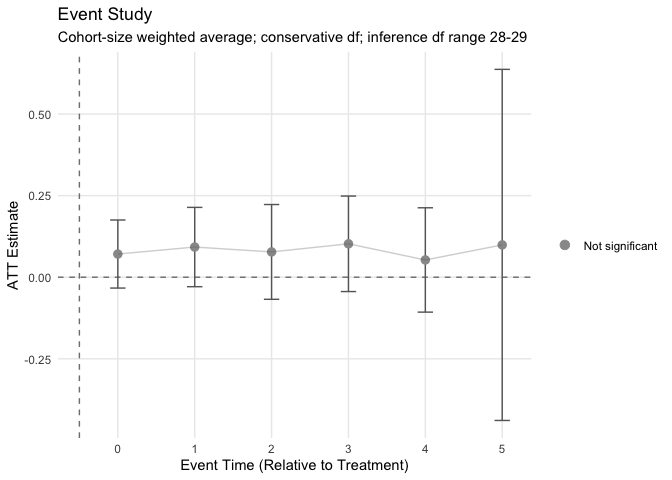

```r
# Post-treatment path only
plot(result_event, show_pre_treatment = FALSE)
```

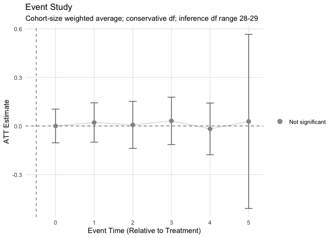

```r
# Normalize to the treatment period without relabeling it as an anchor
plot(result_event, ref_period = 0)
```

## Control Variables

Controls improve efficiency and relax the parallel trends assumption. They must be **time-invariant** (or pre-treatment averages):

```r
result_ctrl <- lwdid(
  data = castle,
  y = "lhomicide",
  ivar = "sid",
  tvar = "year",
  gvar = "gvar",
  rolling = "demean",
  estimator = "ra",
  controls = c("police", "income", "poverty", "unemployrt"),
  aggregate = "cohort"
)
```

## Robust Variance Estimation

| `vce` | Description |
| --- | --- |
| `NULL` | OLS (homoskedastic) |
| `"robust"` / `"hc1"` | HC1 heteroskedasticity-robust |
| `"hc3"` | HC3 (recommended for small samples) |
| `"cluster"` | Cluster-robust (requires `cluster_var`) |

```r
# HC1 is recommended for the smoking data (single treated unit makes HC3
# numerically unstable due to hat value = 1)
result_hc1 <- suppressWarnings(lwdid(
  data = smoking,
  y = "lcigsale",
  ivar = "state",
  tvar = "year",
  d = "d",
  post = "post",
  rolling = "demean",
  estimator = "ra",
  vce = "hc1"
))

summary(result_hc1)
```

```
#>
#> Lee-Wooldridge DiD Estimation
#> ==============================================================================
#>   Method:       common_timing            Dep. var:      lcigsale
#>   Estimator:    ra                       VCE:           HC1 (Heteroskedasticity-robust)
#>   Transform:    demean                   df:            37
#>   Pre-periods:  K = 19                   Post start:    tpost1 = 20
#> ------------------------------------------------------------------------------
#>
#> Overall ATT:
#>                 Estimate  Std. Err.    t value Pr(>|t|)       CI lower   CI upper
#>   ATT        -0.4222     0.0196   -21.5436   <0.001 ***    -0.4619    -0.3825
#>   ---
#>   Signif. codes:  0 '***' 0.001 '**' 0.01 '*' 0.05 '.' 0.1 ' ' 1
#>
#> Regression Coefficients:
#>   ----------------------------------------------------------
#>   Term               Estimate  Std. Err.    t value Pr(>|t|)
#>   ----------------------------------------------------------
#>   (Intercept)         -0.2462
#>   D                   -0.4222
#>   ----------------------------------------------------------
#>
#> Period-Specific Effects:
#>   ----------------------------------------------------------------------------
#>     Period        ATT  Std. Err.     t-stat  p-value       CI lower   CI upper
#>   ----------------------------------------------------------------------------
#>       1989    -0.1682     0.0155   -10.8241   <0.001 ***    -0.1997    -0.1367
#>       1990    -0.1875     0.0181   -10.3490   <0.001 ***    -0.2242    -0.1508
#>       1991    -0.3025     0.0189   -15.9776   <0.001 ***    -0.3408    -0.2641
#>       1992    -0.3101     0.0208   -14.9328   <0.001 ***    -0.3522    -0.2681
#>       1993    -0.3668     0.0197   -18.6570   <0.001 ***    -0.4066    -0.3269
#>       1994    -0.4397     0.0203   -21.6967   <0.001 ***    -0.4808    -0.3987
#>       1995    -0.4835     0.0223   -21.6846   <0.001 ***    -0.5287    -0.4383
#>       1996    -0.4975     0.0226   -22.0443   <0.001 ***    -0.5432    -0.4518
#>       1997    -0.5134     0.0241   -21.2671   <0.001 ***    -0.5623    -0.4645
#>       1998    -0.5308     0.0245   -21.6495   <0.001 ***    -0.5805    -0.4812
#>       1999    -0.5988     0.0251   -23.8295   <0.001 ***    -0.6497    -0.5479
#>       2000    -0.6673     0.0267   -25.0291   <0.001 ***    -0.7213    -0.6133
#>   ----------------------------------------------------------------------------
#>   Period-by-period effects are available in results$att_by_period.
#> ==============================================================================
#>   N = 39    N_treated = 1    N_control = 38    K = 19    tpost1 = 20
```

## Extracting Results

```r
coef(result)
```

```
#>        ATT
#> -0.4221746
```

```r
confint(result)
```

```
#>          2.5 %     97.5 %
#> ATT -0.6669377 -0.1774115
```

```r
vcov(result)
```

```
#>            ATT
#> ATT 0.01459252
```

```r
nobs(result)
```

```
#> [1] 39
```

## Parallel Computation

For staggered designs with many cohort-period pairs, enable parallel processing:

```r
result_par <- lwdid(
  data = castle,
  y = "lhomicide",
  ivar = "sid",
  tvar = "year",
  gvar = "gvar",
  rolling = "demean",
  estimator = "ra",
  aggregate = "cohort",
  parallel = TRUE,
  n_cores = 4
)
```

## Next Steps

- `vignette("advanced-usage")`: IPW, IPWRA, PSM, sensitivity analysis, diagnostics, WCB, RI, data preprocessing
- `vignette("methodology")`: mathematical framework and identification

## References

Lee, S. and Wooldridge, J.M. (2025). “A Simple Transformation Approach to Difference-in-Differences Estimation for Panel Data.”

Lee, S. and Wooldridge, J.M. (2026). “Simple Approaches to Inference with Difference-in-Differences Estimators with Small Cross-Sectional Sample Sizes.”